# Практическая работа. Формирование выборки

Оценивание средней массы тела пингвинов по данным Palmer Penguins

Маркин Никита Алексеевич, Б24-902

23 октября 2026 г.

# Цель и условия работы

Сформировать простые случайные и стратифицированные выборки с возвращением и без возвращения, спланировать их общий объем по разведочной выборке и сравнить распределения оценок средней массы тела.

Генеральная совокупность в этой работе — **все 342 записи с известной массой тела** из набора `penguins`. Выводы относятся к этой конечной совокупности, а не ко всем пингвинам Антарктики. Признак стратификации — вид пингвина.

```r
confidence <- 0.95
delta <- 150          # Допустимая предельная ошибка, г
pilot_size <- 25L
B <- 1000L            # Число реализаций каждого метода
```

# 1. Изучение генеральной совокупности

Если пакет еще не установлен, перед первым запуском следует выполнить `install.packages("palmerpenguins")`. Для подготовки отчета также нужны `knitr` и `rmarkdown`; Pandoc входит в RStudio. Все статистические расчеты и гистограммы далее выполнены средствами базового R.

```r
library(palmerpenguins)

population <- as.data.frame(
  penguins[!is.na(penguins$body_mass_g),
           c("species", "body_mass_g")]
)
rownames(population) <- NULL

# После этой подготовки порядок строк population не изменяется.
N <- nrow(population)
y <- population$body_mass_g
stratum_levels <- c("Adelie", "Chinstrap", "Gentoo")
stratum_rows <- lapply(stratum_levels, function(h) {
  which(population$species == h)
})
names(stratum_rows) <- stratum_levels
N_h <- vapply(stratum_rows, length, integer(1))
W_h <- N_h / N

stopifnot(N == 342L, sum(N_h) == N, !anyNA(y))

# Эталон используется только при описании совокупности и сравнении оценок.
mu_population <- mean(y)
variance_population <- mean((y - mu_population)^2)

population_summary <- data.frame(
  Показатель = c("Число наблюдений", "Средняя масса, г",
                "Дисперсия совокупности (делитель N), г²"),
  Значение = c(N, mu_population, variance_population),
  check.names = FALSE
)
knitr::kable(population_summary, digits = 3, row.names = FALSE)
```

| Показатель | Значение |
| --- | --- |
| Число наблюдений | 342.000 |
| Средняя масса, г | 4201.754 |
| Дисперсия совокупности (делитель N), г² | 641250.577 |

```r
stratum_summary <- data.frame(
  Вид = stratum_levels,
  Численность = as.integer(N_h),
  Доля = as.numeric(W_h),
  `Средняя масса, г` = vapply(stratum_rows, function(idx) mean(y[idx]), numeric(1)),
  check.names = FALSE
)
knitr::kable(stratum_summary, digits = 3, row.names = FALSE)
```

| Вид | Численность | Доля | Средняя масса, г |
| --- | --- | --- | --- |
| Adelie | 151 | 0.442 | 3700.662 |
| Chinstrap | 68 | 0.199 | 3733.088 |
| Gentoo | 123 | 0.360 | 5076.016 |

Дисперсия конечной совокупности рассчитана с делителем $N$:

$$\sigma_N^2=\frac{1}{N}\sum_{i=1}^{N}(y_i-\mu)^2.$$

Средняя масса всей совокупности — **4201.754 г**. Средние массы по видам различаются; это дает основание проверить, улучшает ли стратификация точность оценки общей средней массы.

# 2. Разведочная выборка и планирование объема

Используются ровно те номера строк, которые заданы в условии. Наблюдения разведочной выборки остаются в `population` и доступны для всех последующих отборов.

```r
pilot_idx <- c(
    1, 15, 23, 26, 34,
   35, 43, 51, 61, 89,
  109, 119, 191, 193, 196,
  206, 211, 245, 262, 271,
  284, 286, 292, 314, 331
)

pilot_sample <- population[pilot_idx, , drop = FALSE]
stopifnot(nrow(pilot_sample) == pilot_size,
          length(unique(pilot_idx)) == pilot_size)

pilot_mean <- mean(pilot_sample$body_mass_g)
s2_pilot <- var(pilot_sample$body_mass_g)  # Делитель: pilot_size - 1
alpha <- 1 - confidence
t_critical <- qt(1 - alpha / 2, df = pilot_size - 1)
```

Исправленная выборочная дисперсия и квантиль Стьюдента:

$$s_0^2=\frac{\sum_{i=1}^{m}(y_i-\bar y_0)^2}{m-1},
\qquad t=t_{1-\alpha/2,\,m-1},\qquad m=25.$$

Для простого случайного бесповторного отбора используем приближение предельной ошибки с поправкой на конечную совокупность:

$$\Delta\approx t\sqrt{\frac{s_0^2}{n}\left(1-\frac{n}{N}\right)}.$$

Здесь исправленная разведочная дисперсия оценивает дисперсию с делителем $N-1$, поэтому формула объема имеет вид

$$n_{\mathrm{расч}}=\frac{N t^2s_0^2}{N\Delta^2+t^2s_0^2},
\qquad n=\left\lceil n_{\mathrm{расч}}\right\rceil.$$

```r
n_calculated <- N * t_critical^2 * s2_pilot /
  (N * delta^2 + t_critical^2 * s2_pilot)
n <- as.integer(ceiling(n_calculated))

planned_error <- function(k) {
  t_critical * sqrt(s2_pilot / k * (1 - k / N))
}

stopifnot(n >= 1L, n <= N,
          planned_error(n) <= delta,
          n == 1L || planned_error(n - 1L) > delta)

planning_table <- data.frame(
  Показатель = c("Объем разведочной выборки",
                "Разведочное среднее, г",
                "Исправленная разведочная дисперсия, г²",
                "Квантиль t(0,975; 24)",
                "Расчетный объем до округления",
                "Объем n после округления вверх",
                "Расчетная предельная ошибка при n, г"),
  Значение = c(pilot_size, pilot_mean, s2_pilot, t_critical,
              n_calculated, n, planned_error(n)),
  check.names = FALSE
)
knitr::kable(planning_table, digits = 4, row.names = FALSE)
```

| Показатель | Значение |
| --- | --- |
| Объем разведочной выборки | 25.0000 |
| Разведочное среднее, г | 4348.0000 |
| Исправленная разведочная дисперсия, г² | 635412.5000 |
| Квантиль t(0,975; 24) | 2.0639 |
| Расчетный объем до округления | 88.9931 |
| Объем n после округления вверх | 89.0000 |
| Расчетная предельная ошибка при n, г | 149.9921 |

Подстановка:

$$n_{\mathrm{расч}}=
\frac{342\cdot2.063899^2\cdot635412.5}
{342\cdot150^2+2.063899^2\cdot635412.5}
\approx 88.993078,\qquad n=89.$$

Во всех четырех экспериментах применяется **одно и то же $n=89$**. Расчет приближенный: он основан на разведочной дисперсии и не гарантирует, что ошибка каждой реализации не превысит 150 г. Эталонное среднее при планировании объема не используется.

# 3. Четыре схемы выборочного отбора

## 3.1. Пропорциональное распределение по стратам

Для каждой страты сначала рассчитываем $a_h=nN_h/N$ и берем целую часть. Оставшиеся места распределяем по убыванию дробных остатков. При равенстве остатков сохраняем порядок Adelie, Chinstrap, Gentoo.

```r
allocation_exact <- n * W_h
n_h <- as.integer(floor(allocation_exact))
remaining <- n - sum(n_h)

if (remaining > 0L) {
  priority <- order(-(allocation_exact - n_h), seq_along(n_h))
  chosen_strata <- priority[seq_len(remaining)]
  n_h[chosen_strata] <- n_h[chosen_strata] + 1L
}
names(n_h) <- stratum_levels

stopifnot(sum(n_h) == n, all(n_h > 0L), all(n_h <= N_h))

allocation_table <- data.frame(
  Вид = stratum_levels,
  N_h = as.integer(N_h),
  W_h = as.numeric(W_h),
  `n × W_h` = as.numeric(allocation_exact),
  n_h = as.integer(n_h),
  check.names = FALSE
)
knitr::kable(allocation_table, digits = 4, row.names = FALSE)
```

| Вид | N_h | W_h | n × W_h | n_h |
| --- | --- | --- | --- | --- |
| Adelie | 151 | 0.4415 | 39.2953 | 39 |
| Chinstrap | 68 | 0.1988 | 17.6959 | 18 |
| Gentoo | 123 | 0.3596 | 32.0088 | 32 |

Для ПСВ и ПСБ оценка — обычное среднее по отобранным наблюдениям. Для СТВ и СТБ оценка — взвешенное среднее средних по стратам:

$$\widehat\mu_{\mathrm{стр}}=\sum_{h=1}^{3}W_h\bar y_h,
\qquad W_h=\frac{N_h}{N}.$$

Используются доли страт **в генеральной совокупности**, а не доли в округленном распределении выборки. Поэтому округление $n_h$ не подменяет веса $W_h$. Общая средняя совокупности в формулах выборочных оценок не используется.

## 3.2. Реализация и воспроизводимость

- **ПСВ** — $n$ случайных номеров из всей совокупности с возвращением.
- **ПСБ** — $n$ различных случайных номеров из всей совокупности.
- **СТВ** — $n_h$ номеров внутри каждого вида с возвращением.
- **СТБ** — $n_h$ различных номеров внутри каждого вида без возвращения.

```r
draw_simple_mean <- function(replace) {
  idx <- sample.int(N, size = n, replace = replace)
  mean(y[idx])
}

draw_stratified_mean <- function(replace) {
  stratum_means <- numeric(length(stratum_rows))
  for (h in seq_along(stratum_rows)) {
    rows_h <- stratum_rows[[h]]
    idx_h <- rows_h[sample.int(length(rows_h),
                              size = n_h[h], replace = replace)]
    stratum_means[h] <- mean(y[idx_h])
  }
  sum(W_h * stratum_means)
}

RNGkind(kind = "Mersenne-Twister", normal.kind = "Inversion",
        sample.kind = "Rejection")
seed <- 20261023L
set.seed(seed)
initial_rng_state <- .Random.seed

estimates <- list(PSV = numeric(B), PSB = numeric(B),
                  STV = numeric(B), STB = numeric(B))

# Генератор не переинициализируется между реализациями и методами.
for (b in seq_len(B)) {
  estimates$PSV[b] <- draw_simple_mean(replace = TRUE)
  estimates$PSB[b] <- draw_simple_mean(replace = FALSE)
  estimates$STV[b] <- draw_stratified_mean(replace = TRUE)
  estimates$STB[b] <- draw_stratified_mean(replace = FALSE)
}

method_labels <- c(PSV = "ПСВ", PSB = "ПСБ", STV = "СТВ", STB = "СТБ")
method_names <- c(PSV = "Простой повторный",
                  PSB = "Простой бесповторный",
                  STV = "Стратифицированный повторный",
                  STB = "Стратифицированный бесповторный")

stopifnot(length(estimates) == 4L,
          all(lengths(estimates) == B),
          all(is.finite(unlist(estimates, use.names = FALSE))))
```

Начальное состояние задано через **`set.seed(20261023)`**; алгоритмы: Mersenne-Twister / Inversion / Rejection. Полный начальный вектор состояния сохранен в объекте `initial_rng_state`. Получены четыре массива по **1000 оценок**, каждая оценка основана на **89 наблюдениях**. Повторения внутри повторной выборки считаются отдельными отборами.

# 4. Ошибки и характеристики оценок

Для метода $j$ и реализации $b$ знаковая ошибка равна $e_{jb}=\widehat\mu_{jb}-\mu$. По всем $B=1000$ реализациям рассчитываем:

$$\overline{\widehat\mu}_j=\frac{1}{B}\sum_b\widehat\mu_{jb},
\qquad \mathrm{Bias}_j=\frac{1}{B}\sum_b e_{jb},$$

$$\mathrm{SE}_{\mathrm{эмп},j}=
\sqrt{\frac{\sum_b(\widehat\mu_{jb}-\overline{\widehat\mu}_j)^2}{B-1}},
\qquad \mathrm{RMSE}_j=\sqrt{\frac{1}{B}\sum_b e_{jb}^2},$$

$$p_j=\frac{1}{B}\sum_b\mathbf{1}\{|e_{jb}|\leq150\}.$$

```r
errors <- lapply(estimates, function(x) x - mu_population)

statistics <- vapply(names(estimates), function(method) {
  x <- estimates[[method]]
  e <- errors[[method]]
  c(mean_estimate = mean(x),
    bias = mean(e),
    empirical_se = sd(x),
    rmse = sqrt(mean(e^2)),
    acceptable_share = mean(abs(e) <= delta))
}, numeric(5))
colnames(statistics) <- unname(method_labels[names(estimates)])
```

Все пять показателей относятся к распределению **1000 оценок**, а не к одной выборке. Эмпирическая стандартная ошибка — стандартное отклонение этих оценок, а не разброс индивидуальных масс пингвинов.

# 5. Графики

## Рисунок 1. Распределения оценок средней массы

У четырех гистограмм общие границы оси массы, шаг интервалов **25 г** и единая шкала частот. Красная линия отмечает эталонное среднее совокупности.

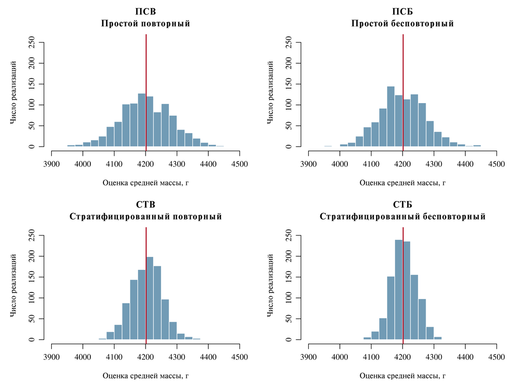

Рисунок 1. Гистограммы 1000 оценок средней массы для четырех методов. Красная линия — эталонное среднее.

```r
bin_width <- 25
all_estimates <- unlist(estimates, use.names = FALSE)
mass_breaks <- seq(
  floor(min(all_estimates) / bin_width) * bin_width,
  ceiling(max(all_estimates) / bin_width) * bin_width,
  by = bin_width
)

plot_four_histograms <- function(values, breaks, reference_lines,
                                 line_colors, line_types, x_label) {
  histograms <- lapply(values, function(x) hist(x, breaks = breaks,
                                               plot = FALSE))
  y_max <- max(vapply(histograms, function(h) max(h$counts), numeric(1)))
  old_par <- par(mfrow = c(2, 2), mar = c(4.3, 4.5, 3.5, 1),
                 mgp = c(2.7, 0.8, 0), family = "serif", cex = 0.95)
  on.exit(par(old_par))
  for (method in names(values)) {
    plot(histograms[[method]], freq = TRUE,
         main = paste(method_labels[method], method_names[method], sep = "\n"),
         xlab = x_label, ylab = "Число реализаций",
         xlim = range(breaks), ylim = c(0, y_max * 1.08),
         col = "#719bb5", border = "white")
    abline(v = reference_lines, col = line_colors, lty = line_types, lwd = 2)
  }
  invisible(NULL)
}

plot_four_histograms(estimates, mass_breaks,
                     reference_lines = mu_population,
                     line_colors = "#b2182b", line_types = 1,
                     x_label = "Оценка средней массы, г")
```

## Рисунок 2. Распределения знаковых ошибок

У четырех гистограмм общие симметричные границы горизонтальной оси, шаг интервалов **25 г** и единая шкала частот. Сплошная линия — 0 г; красные пунктирные линии — −150 и +150 г.

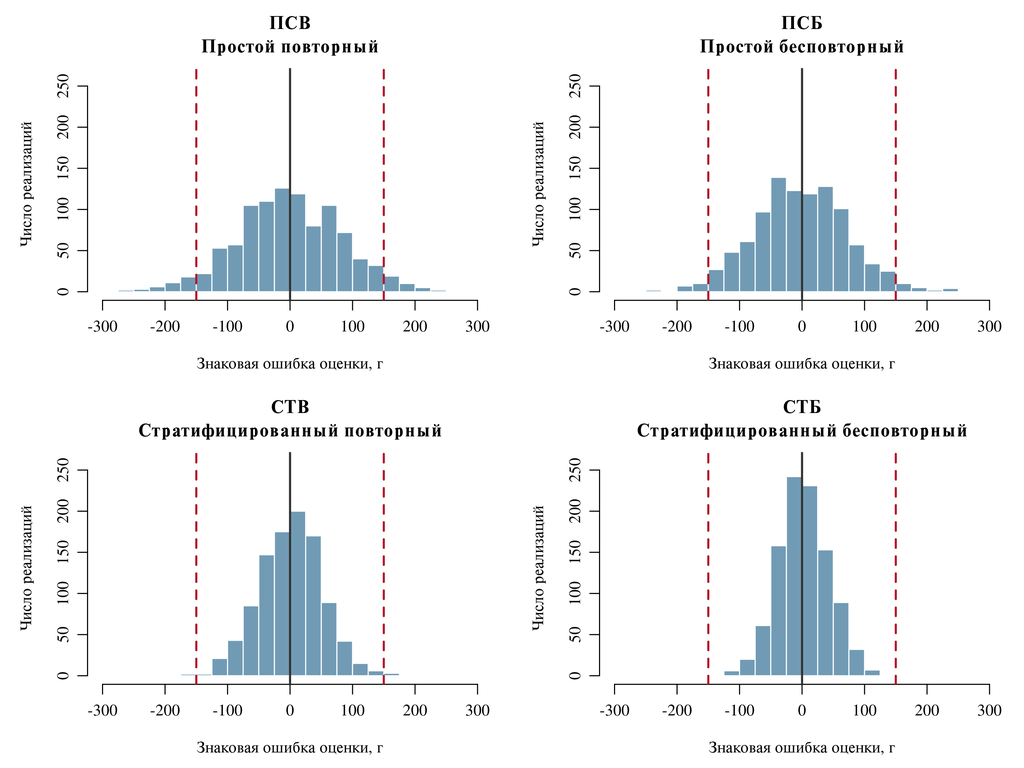

Рисунок 2. Гистограммы знаковых ошибок. Сплошная линия — нулевая ошибка; красные пунктирные линии — границы ±150 г.

```r
all_errors <- unlist(errors, use.names = FALSE)
error_limit <- ceiling(max(abs(all_errors), delta) / bin_width) * bin_width
error_breaks <- seq(-error_limit, error_limit, by = bin_width)

plot_four_histograms(errors, error_breaks,
                     reference_lines = c(-delta, 0, delta),
                     line_colors = c("#b2182b", "#333333", "#b2182b"),
                     line_types = c(2, 1, 2),
                     x_label = "Знаковая ошибка оценки, г")
```

# 6. Сравнение методов и выводы

## Сравнительная таблица

```r
comparison <- data.frame(
  Показатель = c("Среднее из 1000 оценок, г",
                "Эмпирическое смещение, г",
                "Эмпирическая стандартная ошибка, г",
                "RMSE, г",
                "Доля оценок с абсолютной ошибкой не более 150 г"),
  statistics,
  check.names = FALSE
)
knitr::kable(comparison, digits = 3, row.names = FALSE)
```

| Показатель | ПСВ | ПСБ | СТВ | СТБ |
| --- | --- | --- | --- | --- |
| Среднее из 1000 оценок, г | 4201.487 | 4199.629 | 4202.782 | 4204.041 |
| Эмпирическое смещение, г | -0.267 | -2.125 | 1.028 | 2.286 |
| Эмпирическая стандартная ошибка, г | 84.261 | 74.019 | 49.876 | 40.281 |
| RMSE, г | 84.219 | 74.013 | 49.862 | 40.326 |
| Доля оценок с абсолютной ошибкой не более 150 г | 0.921 | 0.959 | 0.995 | 1.000 |

```r
best_se <- which.min(statistics["empirical_se", ])
best_rmse <- which.min(statistics["rmse", ])
best_coverage <- which(statistics["acceptable_share", ] ==
                       max(statistics["acceptable_share", ]))
se_reduction_simple <- 100 * (1 - statistics["empirical_se", "ПСБ"] /
                               statistics["empirical_se", "ПСВ"])
se_reduction_stratified <- 100 * (1 - statistics["empirical_se", "СТБ"] /
                                   statistics["empirical_se", "СТВ"])
stratification_reduction_wr <- 100 * (1 - statistics["empirical_se", "СТВ"] /
                                       statistics["empirical_se", "ПСВ"])
stratification_reduction_wor <- 100 * (1 - statistics["empirical_se", "СТБ"] /
                                        statistics["empirical_se", "ПСБ"])
```

Доли в последней строке представлены числами от 0 до 1; для перевода в проценты их нужно умножить на 100. Округление применяется только при выводе таблицы, а не в расчетах.

## Ответы на вопросы заключения

1. **Какой метод дал наименьший разброс?** Наименьшая эмпирическая стандартная ошибка у метода **СТБ**: **40.281 г**. Его гистограммы наиболее сосредоточены около эталонного среднего и нулевой ошибки при общих шкалах. Минимальный RMSE получен у метода **СТБ**: **40.326 г**.
2. **Как повлиял отбор без возвращения?** По сравнению с ПСВ стандартная ошибка ПСБ уменьшилась на **12.15%**; по сравнению с СТВ стандартная ошибка СТБ уменьшилась на **19.24%**. Бесповторный отбор не расходует часть фиксированного объема на повторное включение тех же записей. При заметной доле обследованной конечной совокупности это уменьшает разброс оценок.
3. **Как повлияла стратификация по видам?** По сравнению с простым отбором стандартная ошибка уменьшилась на **40.81%** при возвращении и на **45.58%** без возвращения. Средняя масса Gentoo заметно выше средних масс Adelie и Chinstrap. Пропорциональный отбор фиксирует представленность каждого вида, уменьшая случайные колебания состава выборки; взвешивание по $W_h$ корректно объединяет средние по стратам.
4. **У какого метода больше всего оценок с допустимой ошибкой?** Наибольшая доля у **СТБ**: **100%**. Объем планировался для ПСБ с ориентиром 95%; фактическая доля для ПСБ равна **95.9%**, то есть отклоняется от ориентира на **0.9 п. п.** Совпадение ровно с 95% не требуется: планирование использует приближение по разведочной дисперсии, а результат 1000 повторений подвержен случайным колебаниям. Тот же $n$ для ПСВ не гарантирует достижения 95%, поскольку при планировании учитывалась поправка именно для бесповторного отбора. При стратификации точность может оказаться выше исходного ориентира.
5. **Можно ли выбрать самый точный метод по одной реализации?** Нет. Даже у метода с меньшей стандартной ошибкой отдельная оценка может случайно оказаться дальше от эталона, чем оценка менее точного метода. Сравнение 1000 реализаций позволяет оценить устойчивый разброс, эмпирическое смещение, RMSE и частоту попадания в допустимые пределы.

Выводы относятся только к конечной совокупности из 342 записей Palmer Penguins. Набор не является случайной выборкой всех пингвинов Антарктики.

# Воспроизводимость и источники

Код расчетов и графиков полностью содержится в этом `.Rmd`. Для повторения нужно открыть файл в RStudio и нажать **Knit**. Дополнительные исходные таблицы не требуются: набор загружается из пакета `palmerpenguins`. В этой работе не строятся доверительные интервалы, не подбирается оптимальное распределение по стратам и не рассчитывается отдельный объем для каждого метода — в соответствии с условием.

```r
data.frame(
  Компонент = c("R", "palmerpenguins", "Начальное значение seed"),
  Версия = c(as.character(getRversion()),
             as.character(packageVersion("palmerpenguins")),
             as.character(seed)),
  check.names = FALSE
)
```

```
##                 Компонент   Версия
## 1                       R    4.5.0
## 2          palmerpenguins    0.1.1
## 3 Начальное значение seed 20261023
```

1. Условие практикума: `practicum_penguins_sampling.pdf`, 5 страниц.
2. Gorman K. B., Williams T. D., Fraser W. R. Ecological Sexual Dimorphism and Environmental Variability within a Community of Antarctic Penguins (Genus Pygoscelis). PLOS ONE. 2014. 9(3): e90081. DOI: 10.1371/journal.pone.0090081.
3. Horst A. M., Hill A. P., Gorman K. B. Palmer Penguins. [Репозиторий пакета](https://github.com/allisonhorst/palmerpenguins).